# Tests of the efficiency of various fMRI designs

Time-stamp: <2013-01-08 17:06 christophe@pallier.org>

Note: This document is generated from a Rmarkdown document that can be processed with knitr and edited with [rstudio](http://www.rstudio.com)

We present some simulations comparing the power of designs with fixed ISI to designs with varying ISI. We are interested in how precise are the estimates of the parameters associated to each condition.

## Basic functions

The basic functions are `dirac.comb` (that generates 0/1 activation vector given onsets and durations of events) and `hrf` (that convolves a timeseries by the impulse HRF)

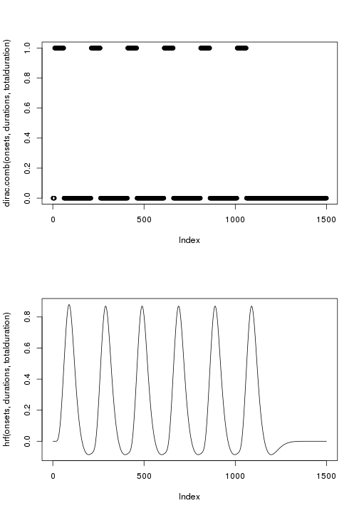

```r
totalduration <- 150
onsets <- seq(1, 120, by = 20)
durations <- 5
par(mfcol = c(2, 1))
plot(dirac.comb(onsets, durations, totalduration))
plot(hrf(onsets, durations, totalduration), type = "l")
```

For multiple conditions, the function `create_design_matrix` reads a table with columns conditions, onsets and durations.

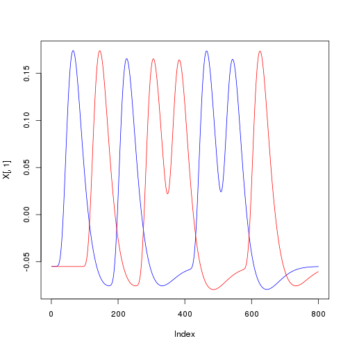

```r
timings <- data.frame(conditions = c(1, 2, 1, 2, 2, 1, 1, 2), onsets = seq(1,
    64, by = 8), durations = 1)
X <- create_design_matrix(timings, totalduration = 80)
par(mfcol = c(1, 1))
plot(X[, 1], type = "l", col = "blue")
lines(X[, 2], type = "l", col = "red")
```

To generate paradigms, one can use higher-level function such as `generate_paradigm_fixed_SOA`

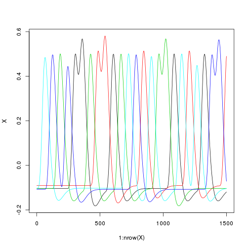

```r
a <- generate_paradigm_fixed_SOA(ncond = 5, trialpercond = 5, stimduration = 3,
    SOA = 6, totalduration = 150)
plot_design_matrix(create_design_matrix(a, totalduration = 150))
```

See also `generate_paradigm_fixed_SOA_adding_silences`, `generate_paradigm_varying_SOA`, `generate_paradigm_varying_SOA_null_events`.

## Parameters for the simulations

```r
ncond <- 4  # number of conditions
trialpercond <- 20
stimduration <- 1  # in sec
SOA <- 4  # in sec
(totalduration <- (ncond * trialpercond * SOA) + SOA)
```

```
## [1] 324
```

Contrasts of interest

```r
(listcon <- list(linear = (1:ncond) - mean(1:ncond), firstbeta = c(1, rep(0,
    ncond - 1))))
```

```
## $linear
## [1] -1.5 -0.5  0.5  1.5
##
## $firstbeta
## [1] 1 0 0 0
```

The number of simulations for each class of designs:

```r
nsim = 10
```

The simulations will use normal noise

```r
normalnoise <- function(npoints) {
    5 * rnorm(npoints)
}
```

## Fixed SOA, no silent trial

Let us generate a paradigm with a fixed SOA…

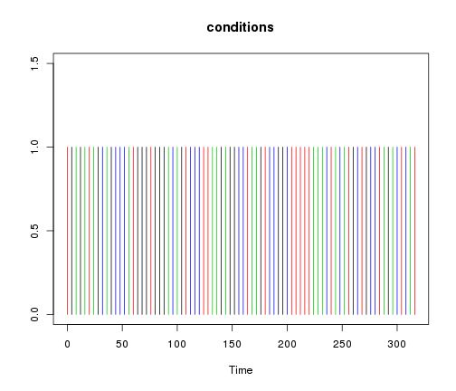

```r
timing <- generate_paradigm_fixed_SOA(ncond, trialpercond, stimduration, SOA,
    totalduration)
plot_paradigm(timing)
```

… and build its associated design matrix

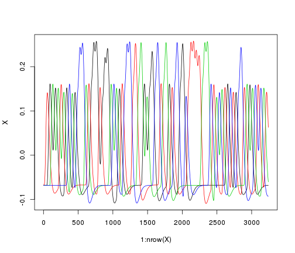

```r
X <- create_design_matrix(timing, totalduration)
plot_design_matrix(X)
```

```r
o <- simulations(nsim, beta = 1:ncond, listofcontrasts = listcon, normalnoise,
    generate_paradigm_fixed_SOA, ncond, trialpercond, stimduration, SOA, totalduration)
```

```r
report <- function(outputsim) {
    par(las = 1)
    boxplot(outputsim$estimates, main = "parameter estimates")
    grid()
    boxplot(outputsim$estimatese, main = "standard errors")
    grid()
    for (col in 1:ncol(outputsim$efficiencies)) boxplot(outputsim$efficiencies[,
        col], main = paste("Efficiency", names(listcon)[col]), horizontal = TRUE)
    grid()
}
```

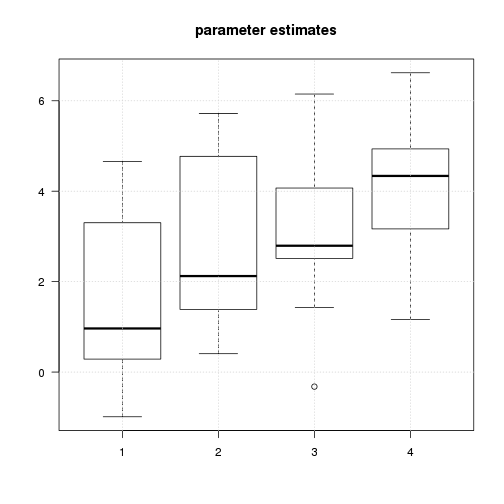

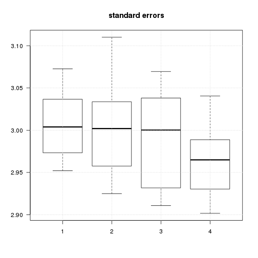

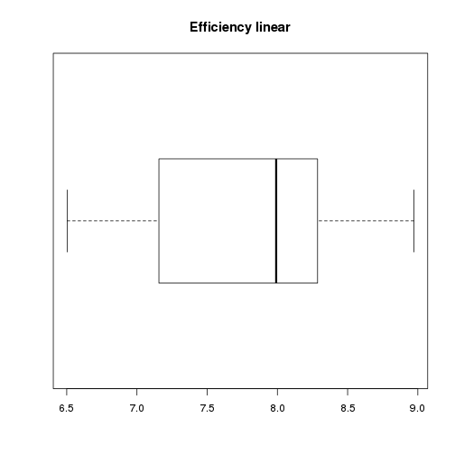

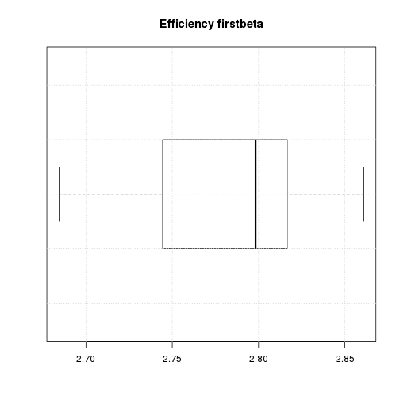

```r
report(o)
```

## Designs with jitter between trials

Now, we jitter the SOA between trials and run a similar simulation.

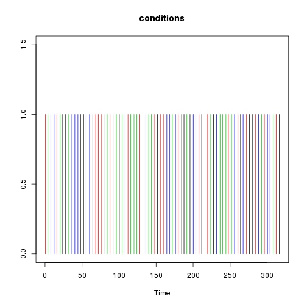

```r
timing <- generate_paradigm_varying_SOA(ncond, trialpercond, stimduration, SOA,
    jitter = 1, totalduration)
plot_paradigm(timing)
```

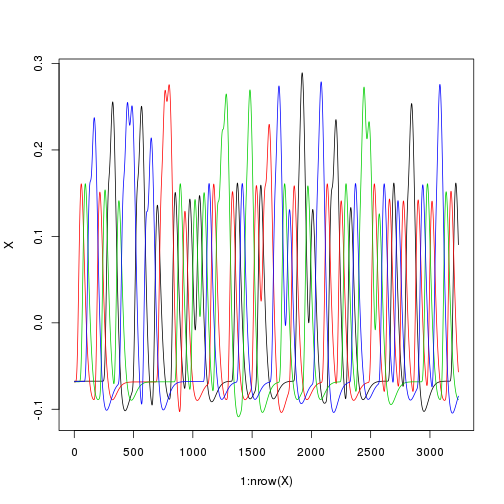

```r
X <- create_design_matrix(timing, totalduration)
plot_design_matrix(X)
```

histogram of SOAs:

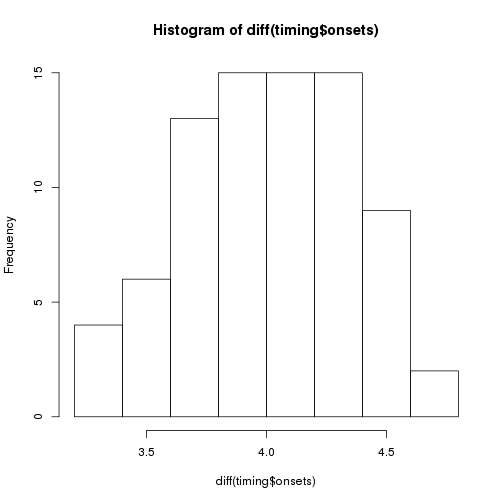

```r
hist(diff(timing$onsets))
```

```r
o2 <- simulations(nsim, beta = 1:ncond, listofcontrasts = listcon, normalnoise,
    generate_paradigm_varying_SOA, ncond, trialpercond, stimduration, 4, SOA,
    totalduration)
```

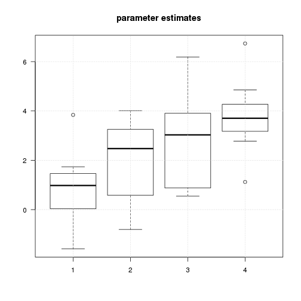

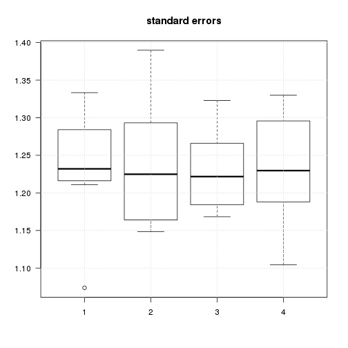

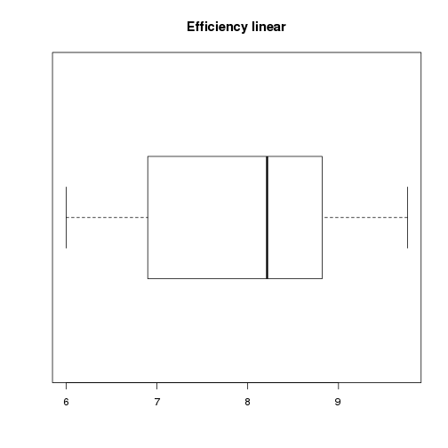

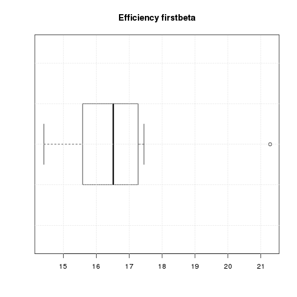

```r
report(o2)
```

## Design with fixed SOA and 'explicit' NULL events

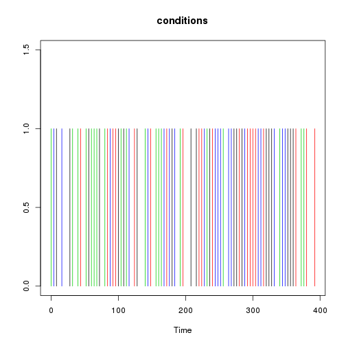

```r
timing <- generate_paradigm_fixed_SOA_adding_silences(ncond, trialpercond, stimduration,
    SOA, totalduration)
plot_paradigm(timing)
```

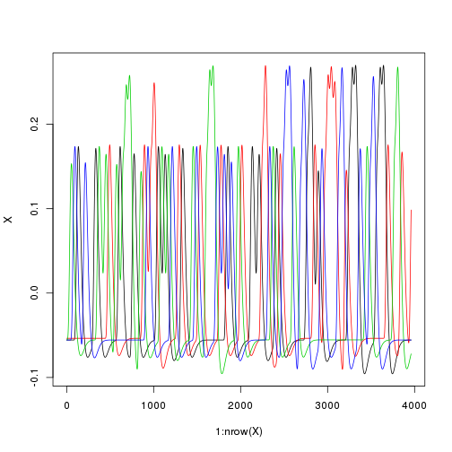

```r
totalduration <- max(timing$onsets) + SOA
X <- create_design_matrix(timing, totalduration)
plot_design_matrix(X)
```

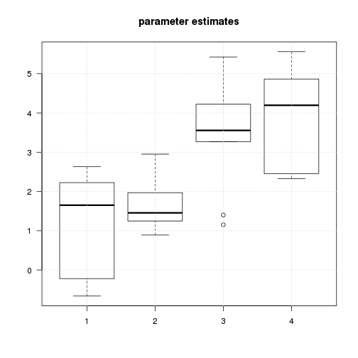

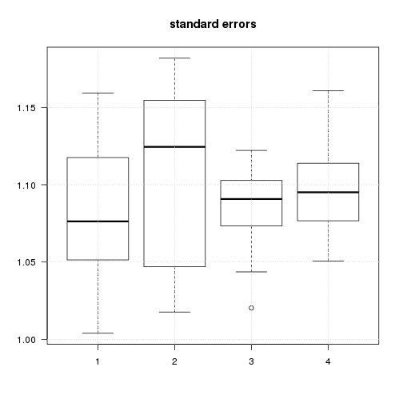

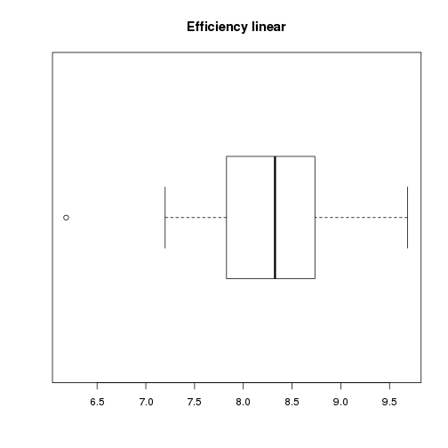

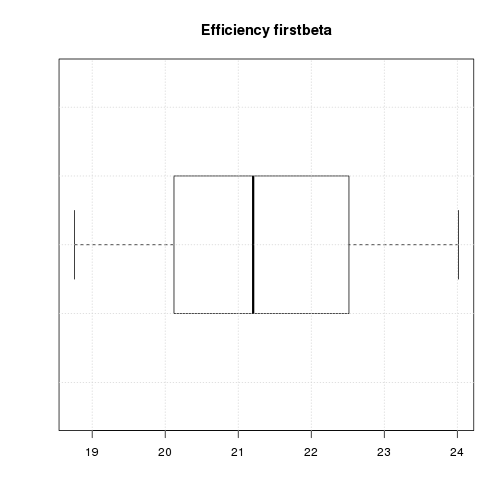

```r
o3 <- simulations(nsim, beta = 1:ncond, listofcontrasts = listcon, normalnoise,
    generate_paradigm_fixed_SOA_adding_silences, ncond, trialpercond, stimduration,
    SOA, totalduration)

report(o3)
```

## Designs with varying ISI (a la optseq)

Here, the same total amount of silence is inserted as NULL events of varying length between the 'real' trials, introducing jitter.

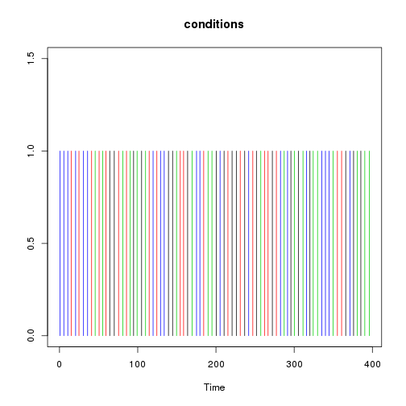

```r
timing <- generate_paradigm_varying_SOA_null_events(ncond, trialpercond, stimduration,
    SOA, totalduration)
plot_paradigm(timing)
```

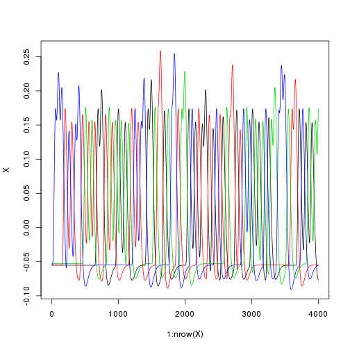

```r
totalduration <- max(timing$onsets) + SOA
X <- create_design_matrix(timing, totalduration)
plot_design_matrix(X)
```

histogram of SOAs:

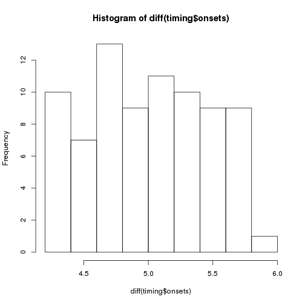

```r
hist(diff(timing$onsets))
```

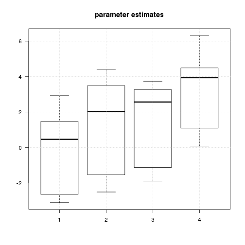

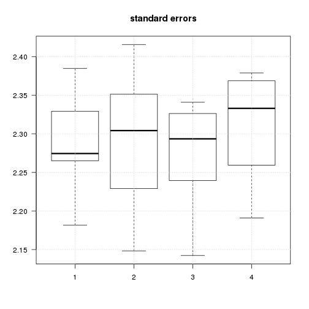

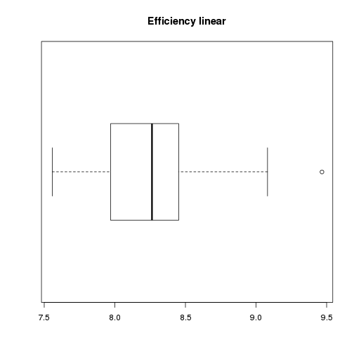

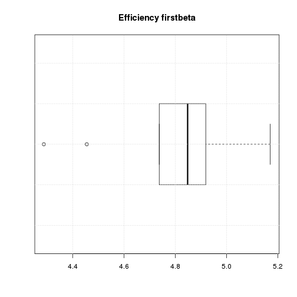

```r
o4 <- simulations(nsim, beta = 1:ncond, listofcontrasts = listcon, normalnoise,
    generate_paradigm_varying_SOA_null_events, ncond, trialpercond, stimduration,
    SOA, totalduration)

report(o4)
```